# STA 326 2.0 Programming and Data Analysis with R

AS2019351

2022-10-05

# Introduction

The epidemic of novel coronavirus illness became as a global threat which was first identified Whuhan in china in December 2019 and it was spreded among more than 188 countries in the world.The symptoms of the disease being more or less similar to those of influenza (flu) or common cold makes it even more difficult to accurately diagnose it without further testing. The disease easily transmitted through direct contact with an infected person or through contaminated surfaces can be fatal in rare cases

Colombia is a country which is affected very badly by this pandamic. The virus was confirmed to have reached Colombia on 6 March 2020 and it affected to the nearly 6,310,000 of colombians and coused 142,000 of deaths.

## People and Religions

The majority of Colombians are ‘mestizos’, meaning they share a mixture of European and Amerindian heritage to some degree. According to the CIA World Factbook, at least 84% of the population are mestizos or European. Approximately 10% of the population possess African heritage – known as Afro-Colombian.

Colombia does not have an official religion. However, Roman Catholicism is the dominant faith and deeply culturally pervasive. While the national department of statistics does not record the religious affiliations of the population, various studies and surveys suggest approximately 90% of Colombians are Christian.

## Location

colombia is the country whoes North is South America, bordering the Caribbean Sea, between Panama and Venezuela, and bordering the North Pacific Ocean, between Ecuador and Panama.It consist a land area of 1.139 million km².The geographical location of Colombia can be further understood through the following figure

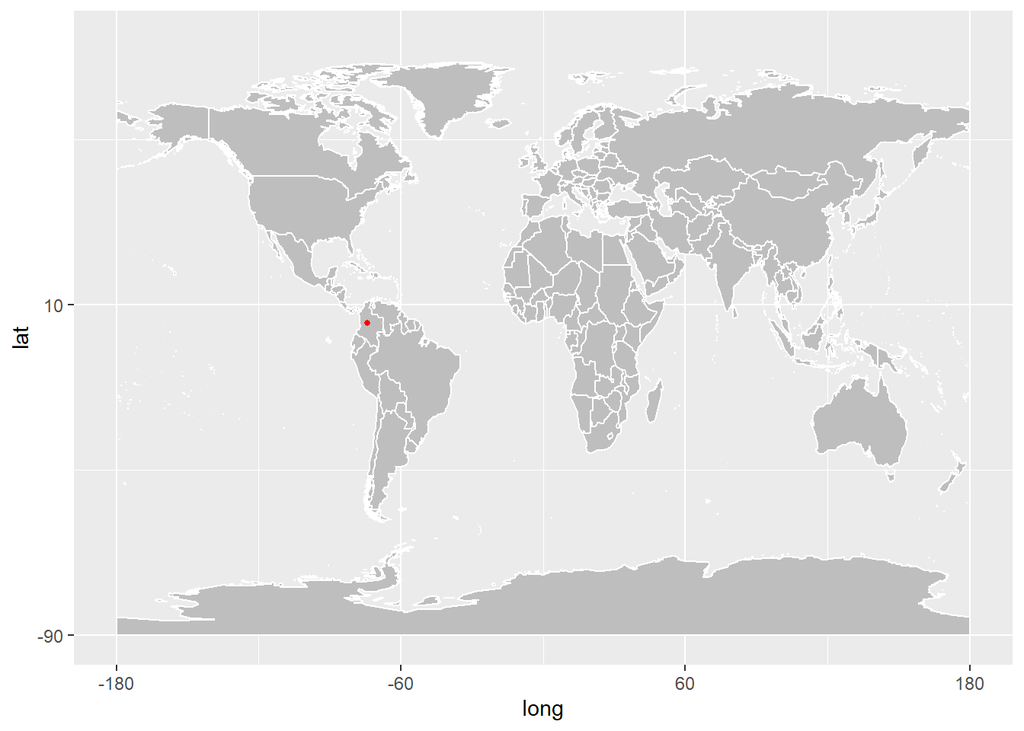

```r
library(ggplot2)
library(maptools)
library(tibble)
library(tidyverse)
library(ggrepel)
library(png)
library(grid)
library(sp)


Colombia_corona<- coronavirus %>% filter(country == "Colombia")

data(wrld_simpl)
p <- ggplot()+
  geom_polygon(data = wrld_simpl,
               aes(x = long, y = lat, group = group), fill = "gray", colour = "white") +
  coord_cartesian(xlim = c(-180, 180), ylim = c(-90, 90)) +
  scale_x_continuous(breaks = seq(-180, 180, 120)) +
  scale_y_continuous(breaks = seq(-90, 90, 100))
  p + geom_point(
    data = Colombia_corona, aes(x = long, y = lat), color = "red" , size = 1
  )
```

## Exploratory Data Analysis

```
##       date              province           country               lat
##  Min.   :2020-01-22   Length:884         Length:884         Min.   :4.571
##  1st Qu.:2020-08-29   Class :character   Class :character   1st Qu.:4.571
##  Median :2021-04-07   Mode  :character   Mode  :character   Median :4.571
##  Mean   :2021-04-07                                         Mean   :4.571
##  3rd Qu.:2021-11-14                                         3rd Qu.:4.571
##  Max.   :2022-06-23                                         Max.   :4.571
##       long           type               cases            uid
##  Min.   :-74.3   Length:884         Min.   :  0.0   Min.   :170
##  1st Qu.:-74.3   Class :character   1st Qu.: 21.0   1st Qu.:170
##  Median :-74.3   Mode  :character   Median :104.5   Median :170
##  Mean   :-74.3                      Mean   :158.3   Mean   :170
##  3rd Qu.:-74.3                      3rd Qu.:241.5   3rd Qu.:170
##  Max.   :-74.3                      Max.   :720.0   Max.   :170
##      iso2               iso3               code3     combined_key
##  Length:884         Length:884         Min.   :170   Length:884
##  Class :character   Class :character   1st Qu.:170   Class :character
##  Mode  :character   Mode  :character   Median :170   Mode  :character
##                                        Mean   :170
##                                        3rd Qu.:170
##                                        Max.   :170
##    population       continent_name     continent_code
##  Min.   :50882884   Length:884         Length:884
##  1st Qu.:50882884   Class :character   Class :character
##  Median :50882884   Mode  :character   Mode  :character
##  Mean   :50882884
##  3rd Qu.:50882884
##  Max.   :50882884
```

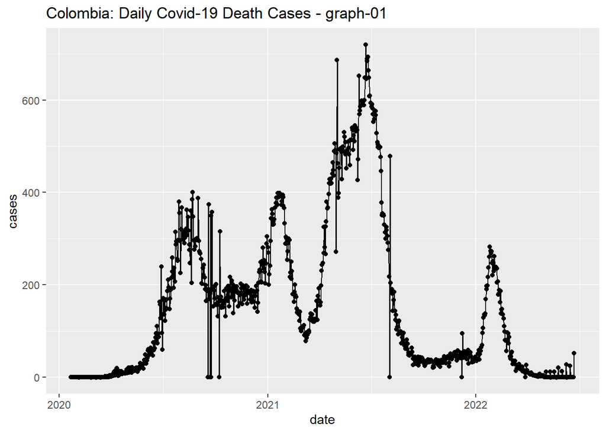

Visualization of death

```
## [1] 2062 2330
```

```
##       date              province           country               lat
##  Min.   :2020-01-22   Length:2652        Length:2652        Min.   :4.571
##  1st Qu.:2020-08-29   Class :character   Class :character   1st Qu.:4.571
##  Median :2021-04-07   Mode  :character   Mode  :character   Median :4.571
##  Mean   :2021-04-07                                         Mean   :4.571
##  3rd Qu.:2021-11-14                                         3rd Qu.:4.571
##  Max.   :2022-06-23                                         Max.   :4.571
##
##       long           type               cases               uid
##  Min.   :-74.3   Length:2652        Min.   :    0.00   Min.   :170
##  1st Qu.:-74.3   Class :character   1st Qu.:    8.25   1st Qu.:170
##  Median :-74.3   Mode  :character   Median :  287.00   Median :170
##  Mean   :-74.3                      Mean   : 4140.69   Mean   :170
##  3rd Qu.:-74.3                      3rd Qu.: 6531.00   3rd Qu.:170
##  Max.   :-74.3                      Max.   :89557.00   Max.   :170
##                                     NA's   :2
##      iso2               iso3               code3     combined_key
##  Length:2652        Length:2652        Min.   :170   Length:2652
##  Class :character   Class :character   1st Qu.:170   Class :character
##  Mode  :character   Mode  :character   Median :170   Mode  :character
##                                        Mean   :170
##                                        3rd Qu.:170
##                                        Max.   :170
##
##    population       continent_name     continent_code
##  Min.   :50882884   Length:2652        Length:2652
##  1st Qu.:50882884   Class :character   Class :character
##  Median :50882884   Mode  :character   Mode  :character
##  Mean   :50882884
##  3rd Qu.:50882884
##  Max.   :50882884
##
```

```
##       date              province           country               lat
##  Min.   :2020-01-22   Length:884         Length:884         Min.   :4.571
##  1st Qu.:2020-08-29   Class :character   Class :character   1st Qu.:4.571
##  Median :2021-04-07   Mode  :character   Mode  :character   Median :4.571
##  Mean   :2021-04-07                                         Mean   :4.571
##  3rd Qu.:2021-11-14                                         3rd Qu.:4.571
##  Max.   :2022-06-23                                         Max.   :4.571
##
##       long           type               cases              uid
##  Min.   :-74.3   Length:884         Min.   :    0.0   Min.   :170
##  1st Qu.:-74.3   Class :character   1st Qu.:    0.0   1st Qu.:170
##  Median :-74.3   Mode  :character   Median :  125.5   Median :170
##  Mean   :-74.3                      Mean   : 5307.8   Mean   :170
##  3rd Qu.:-74.3                      3rd Qu.: 9094.0   3rd Qu.:170
##  Max.   :-74.3                      Max.   :89557.0   Max.   :170
##                                     NA's   :2
##      iso2               iso3               code3     combined_key
##  Length:884         Length:884         Min.   :170   Length:884
##  Class :character   Class :character   1st Qu.:170   Class :character
##  Mode  :character   Mode  :character   Median :170   Mode  :character
##                                        Mean   :170
##                                        3rd Qu.:170
##                                        Max.   :170
##
##    population       continent_name     continent_code
##  Min.   :50882884   Length:884         Length:884
##  1st Qu.:50882884   Class :character   Class :character
##  Median :50882884   Mode  :character   Mode  :character
##  Mean   :50882884
##  3rd Qu.:50882884
##  Max.   :50882884
##
```

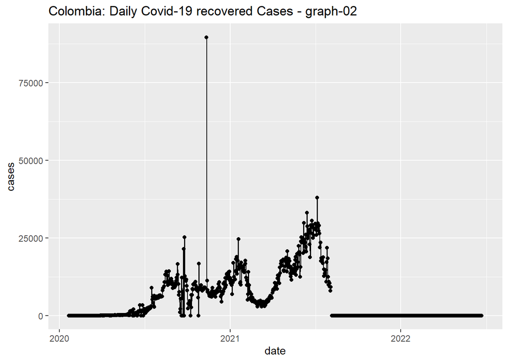

Visualization of recovered cases

```
##       date              province           country               lat
##  Min.   :2020-01-22   Length:884         Length:884         Min.   :4.571
##  1st Qu.:2020-08-29   Class :character   Class :character   1st Qu.:4.571
##  Median :2021-04-07   Mode  :character   Mode  :character   Median :4.571
##  Mean   :2021-04-07                                         Mean   :4.571
##  3rd Qu.:2021-11-14                                         3rd Qu.:4.571
##  Max.   :2022-06-23                                         Max.   :4.571
##       long           type               cases              uid
##  Min.   :-74.3   Length:884         Min.   :    0.0   Min.   :170
##  1st Qu.:-74.3   Class :character   1st Qu.:  776.5   1st Qu.:170
##  Median :-74.3   Mode  :character   Median : 3980.0   Median :170
##  Mean   :-74.3                      Mean   : 6936.3   Mean   :170
##  3rd Qu.:-74.3                      3rd Qu.:10036.2   3rd Qu.:170
##  Max.   :-74.3                      Max.   :35575.0   Max.   :170
##      iso2               iso3               code3     combined_key
##  Length:884         Length:884         Min.   :170   Length:884
##  Class :character   Class :character   1st Qu.:170   Class :character
##  Mode  :character   Mode  :character   Median :170   Mode  :character
##                                        Mean   :170
##                                        3rd Qu.:170
##                                        Max.   :170
##    population       continent_name     continent_code
##  Min.   :50882884   Length:884         Length:884
##  1st Qu.:50882884   Class :character   Class :character
##  Median :50882884   Mode  :character   Mode  :character
##  Mean   :50882884
##  3rd Qu.:50882884
##  Max.   :50882884
```

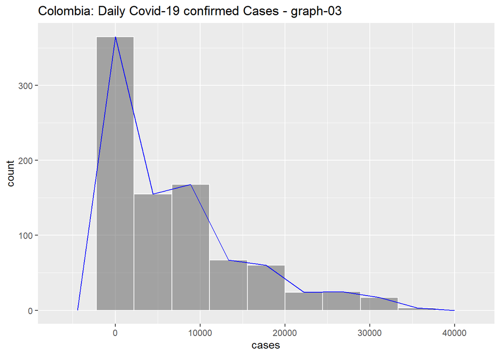

Visualization of confirmed cases

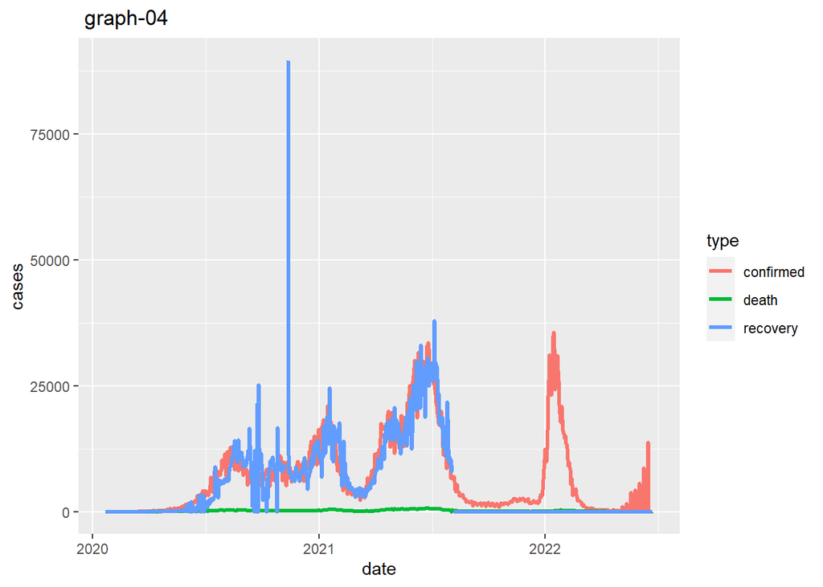

According to this graph can colclute that the controling of corona virus is good with considering the count of death.

### Comparison with other countries

In here Brazi, Lebanon and Colombia are compared according to the count ofconfirmed cases, recoverd cases and deaths.

```
##       date              province           country               lat
##  Min.   :2020-01-22   Length:7956        Length:7956        Min.   :-14.235
##  1st Qu.:2020-08-29   Class :character   Class :character   1st Qu.:-14.235
##  Median :2021-04-07   Mode  :character   Mode  :character   Median :  4.571
##  Mean   :2021-04-07                                         Mean   :  8.064
##  3rd Qu.:2021-11-14                                         3rd Qu.: 33.855
##  Max.   :2022-06-23                                         Max.   : 33.855
##       long            type               cases                uid
##  Min.   :-74.30   Length:7956        Min.   :-17771228   Min.   : 76.0
##  1st Qu.:-74.30   Class :character   1st Qu.:        2   1st Qu.: 76.0
##  Median :-51.93   Mode  :character   Median :      289   Median :170.0
##  Mean   :-30.12                      Mean   :     5033   Mean   :222.7
##  3rd Qu.: 35.86                      3rd Qu.:     4528   3rd Qu.:422.0
##  Max.   : 35.86                      Max.   :   388340   Max.   :422.0
##      iso2               iso3               code3       combined_key
##  Length:7956        Length:7956        Min.   : 76.0   Length:7956
##  Class :character   Class :character   1st Qu.: 76.0   Class :character
##  Mode  :character   Mode  :character   Median :170.0   Mode  :character
##                                        Mean   :222.7
##                                        3rd Qu.:422.0
##                                        Max.   :422.0
##    population        continent_name     continent_code
##  Min.   :  6825442   Length:7956        Length:7956
##  1st Qu.:  6825442   Class :character   Class :character
##  Median : 50882884   Mode  :character   Mode  :character
##  Mean   : 90089245
##  3rd Qu.:212559409
##  Max.   :212559409
```

Summery of the data which includes the data of the country Brazil, Lebanon and Colombia

```
##       date              province           country               lat
##  Min.   :2020-01-22   Length:7956        Length:7956        Min.   :-14.235
##  1st Qu.:2020-08-29   Class :character   Class :character   1st Qu.:-14.235
##  Median :2021-04-07   Mode  :character   Mode  :character   Median :  4.571
##  Mean   :2021-04-07                                         Mean   :  8.064
##  3rd Qu.:2021-11-14                                         3rd Qu.: 33.855
##  Max.   :2022-06-23                                         Max.   : 33.855
##
##       long            type               cases             uid
##  Min.   :-74.30   Length:7956        Min.   :     0   Min.   : 76.0
##  1st Qu.:-74.30   Class :character   1st Qu.:     2   1st Qu.: 76.0
##  Median :-51.93   Mode  :character   Median :   290   Median :170.0
##  Mean   :-30.12                      Mean   :  7932   Mean   :222.7
##  3rd Qu.: 35.86                      3rd Qu.:  4537   3rd Qu.:422.0
##  Max.   : 35.86                      Max.   :388340   Max.   :422.0
##                                      NA's   :7
##      iso2               iso3               code3       combined_key
##  Length:7956        Length:7956        Min.   : 76.0   Length:7956
##  Class :character   Class :character   1st Qu.: 76.0   Class :character
##  Mode  :character   Mode  :character   Median :170.0   Mode  :character
##                                        Mean   :222.7
##                                        3rd Qu.:422.0
##                                        Max.   :422.0
##
##    population        continent_name     continent_code
##  Min.   :  6825442   Length:7956        Length:7956
##  1st Qu.:  6825442   Class :character   Class :character
##  Median : 50882884   Mode  :character   Mode  :character
##  Mean   : 90089245
##  3rd Qu.:212559409
##  Max.   :212559409
##
```

```
## [1] 2062 2330 2804 4387 4392 4982 7634
```

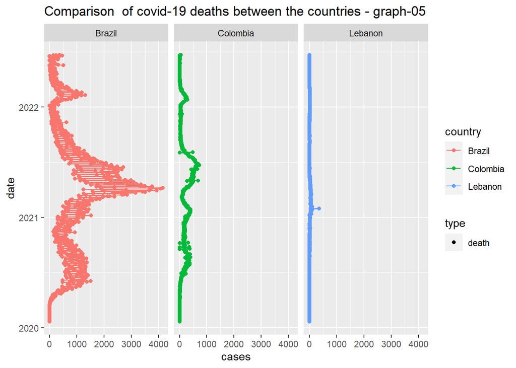

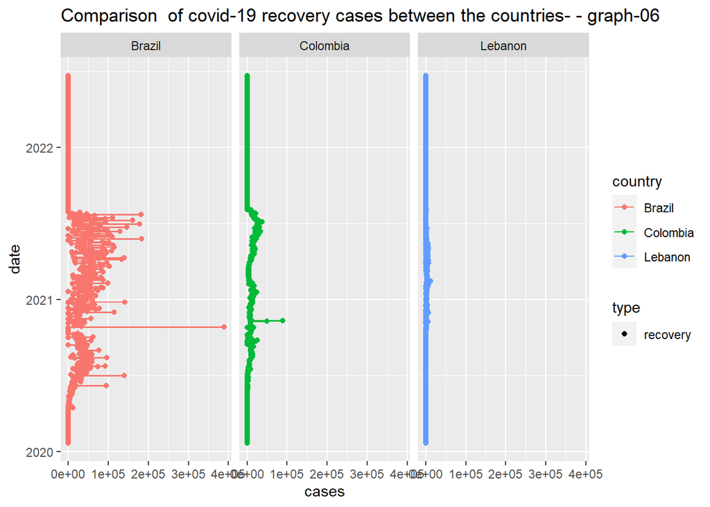

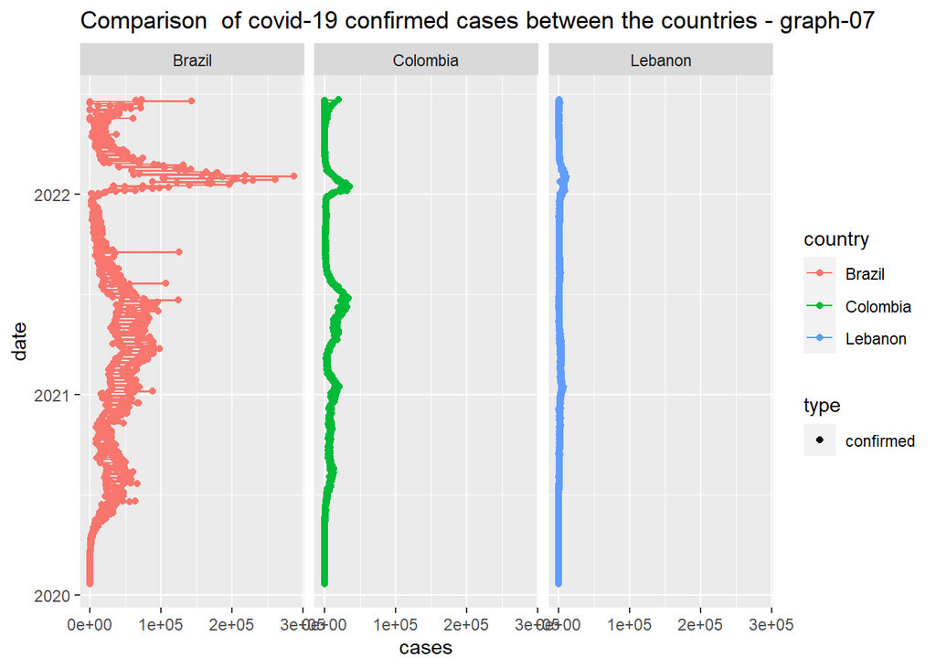

## Conclusions and Discussion

Through the data analysis process it was recognized that there were negative values for confirmed cases of some countries, the main causes may be the fact that at preliminary stages of testing some patients may have been diagnosed as COVID-19 positive and later on diagnosed as negative. Therefore, the data was pre-processed before the actual analysis by coding the negative values as missing values. This is the reason as to why there are discontinuities in some line plots.

*Acoording to the graph-05 clearly it shows us that the Brazil had recorded the heighest count of deaths than Colombia and Lebanon

*According to the graph-06 it shows us clearly that the Brazil had reported a heigher counts than Leabanon and Colombia till the mid of year 2021, after that its not showing a huge differendce between the countries

*According to the graph-07 can clearly see that Brazil recorded a heigher count of confirmed cases from the beging to the end of the data set.In 2022 there is a rapid increasement the count of the confirmed cases in Brazil

Overall the colombia government is having the situation under control

## References

- https://www.google.com/search?q=corona+in++Colombia&sxsrf=ALiCzsY7p03edeX5yP9I8z7oSnJJj1RsHg%3A1665215867710&ei=ey1BY_L_Kt-cz7sP2cOyEA&ved=0ahUKEwiyqZPClND6AhVfznMBHdmhDAIQ4dUDCA4&uact=5&oq=corona+in++Colombia&gs_lcp=Cgdnd3Mtd2l6EAMyBggAEB4QBzIGCAAQHhAHMgcIABCABBAKMgQIABAeMgYI…&sclient=gws-wiz
- https://culturalatlas.sbs.com.au/colombian-culture/colombian-culture-religion